# Question

Our generic quadratic function, $y=ax^2+bx+c$, represents a parabola with a vertical axis of symmetry. The [quadratic formula](https://en.wikipedia.org/wiki/Quadratic_formula#Geometric_significance) allows us to calculate the locations of the roots (the $x$-intercepts… the zeros).

$$\text{roots' horizontal coordinates}
~=~ \frac{-b}{2a} \pm \frac{\sqrt{b^2-4ac}}{2a}$$

The first term, $\frac{-b}{2a}$, indicates the center of the two roots, which occurs at the axis of symmetry. Thus, if the axis of symmetry is line $x=h$ (and the vertex is at $(h,k)$), we now have a shortcut for finding $h$.

$$h=\frac{-b}{2a}$$

The second term, $\frac{\sqrt{b^2-4ac}}{2a}$, represents how far the roots are from the axis of symmetry.

Consider the [quadratic function](https://en.wikipedia.org/wiki/Quadratic_function) defined below.

$$f(x)~=~-3x^2+5x+2$$

Below, I’ve graphed $y=f(x)$, and I’ve included the axis of symmetry.

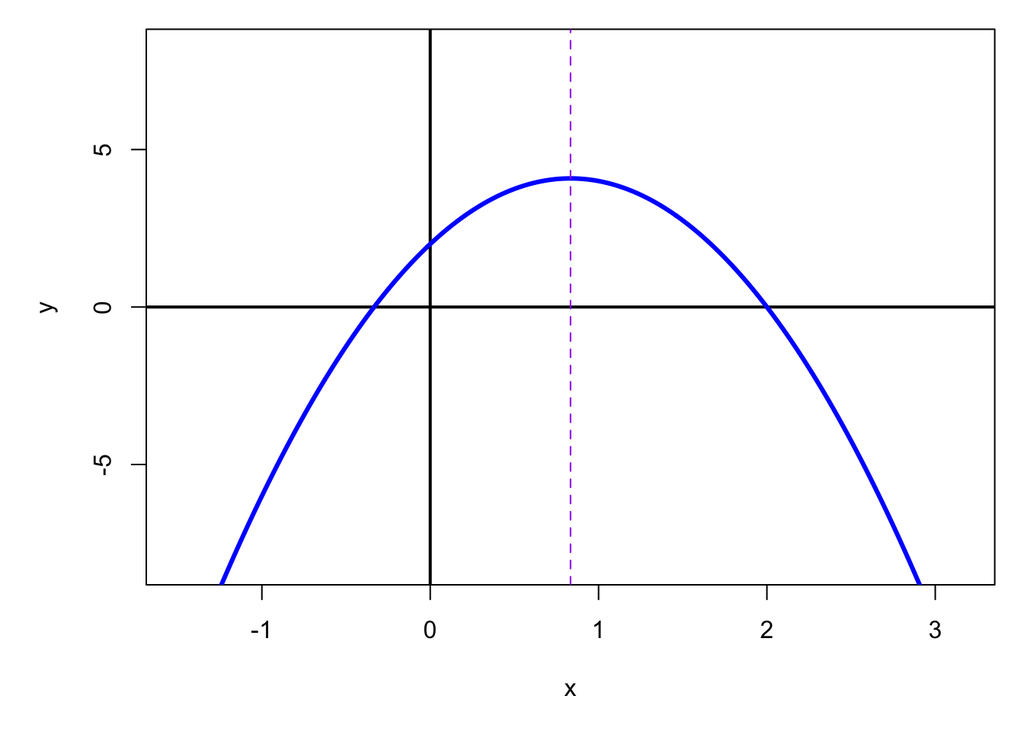

Calculate $h$, the horizontal coordinate of the vertex and the position of the vertical axis of symmetry. *The tolerance is $\pm 0.01$.*

- $h=$

# Solution

The formula for calculating $h$ was given (among a bunch of other information). First, identify the standard-form parameters:

- The quadratic coefficient: $a=-3$
- The linear coefficient: $b=5$
- The constant: $c=2$

Now, use the formula to calculate $h$ from the standard-form parameters:

$$\begin{align}
h &= \frac{-b}{2a} \\\\
&= \frac{-(5)}{2(-3)} \\\\
&= 0.8333333
\end{align}$$

- The axis of symmetry is line $x=0.8333333$.
- The vertex is point $(0.8333333,\,4.0833333)$

# Meta-information

extype: num exsolution: 0.8333333 exname: quad_AOS_from_standard extol: 0.01